# Blockchain data management

Ola Länsman

# Contents

- Definition of blockchain
- Example: Bitcoin
- Bitcoin vs. blockchain

# Definition of blockchain

> While there is no one standard definition of blockchain, the most parsimonious and commonly used is a “distributed ledger of transactions”. This is why the term “blockchain technologies” is often used interchangeably with “distributed ledger technologies”.

# Bitcoin

First blockchain application

## Motivation

Trend of blockchain.

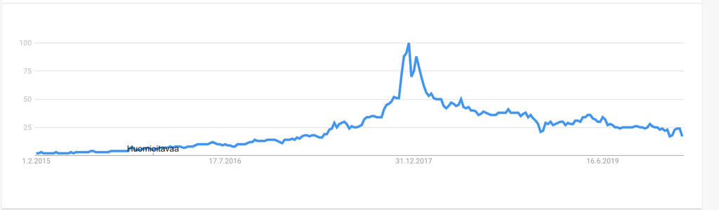

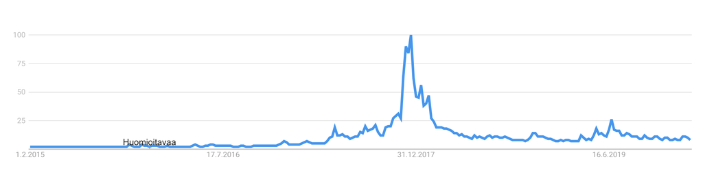

Trend of bitcoin

## Top 3 attributes

1. Decentralization

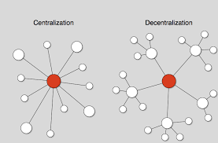

## Top 3 attributes

2. Immutability

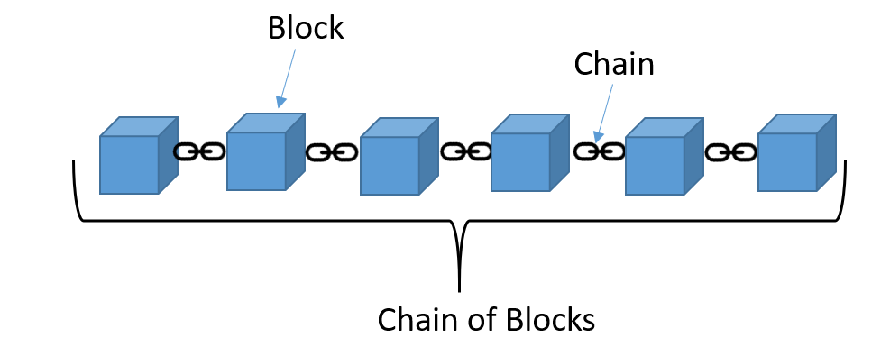

## Top 3 attributes

- 3. Public, yet private
- Public - all transactions are visible
- Yet private - identities of persons are hidden
- (Though identities can be deduced if precautions are not taken)

# But how does it work?

- Data is stored in a chain of blocks
- Consensus by always choosing the longest chain

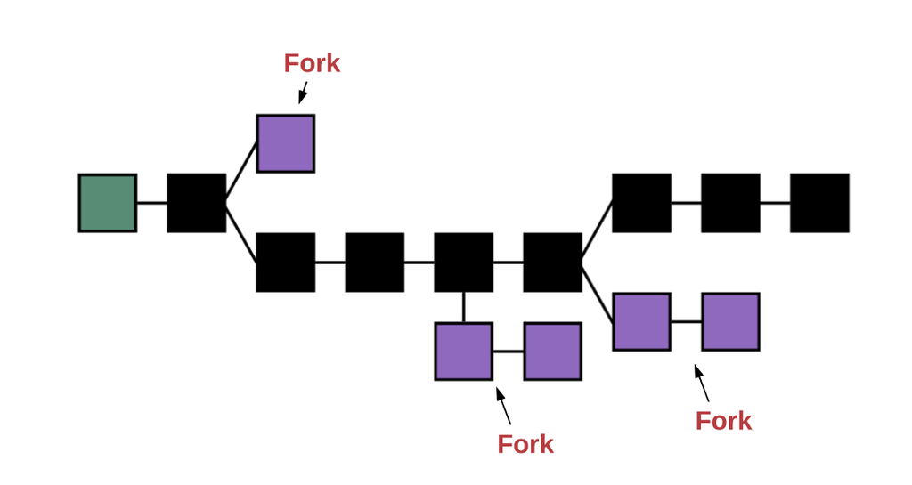

- **Proof-of-work** consensus model

## But how does it work?

- Find a solution to a cryptographic puzzle
- Given a string $\alpha$, find a nonce s.t. Sha-256($\alpha$ + nonce) < threshold
- Nonce = “number only used once”
- Sha-256 hashing algorithm:
  - Deterministic
  - Irreversible
  - Probabilistically unique
  - 2^256

## Cryptographical puzzle

[interactive chart not shown]

## But how does it work?

- Find a solution to a cryptographic puzzle
- Given a string $\alpha$, find a string nonce s.t. Sha-256($\alpha$ + nonce) < threshold
- Difficulty level can be controlled with the difficulty threshold.
- Bitcoin protocol sets the threshold s.t. a new block can be find in $\approx$ 10 minutes
- This process is called **mining**, and the finder of a new block is rewarded with coin

# Okay, but where’s the immutability of the transactions?

- Given a string $\alpha$, find a string nonce s.t. Sha-256($\alpha$ + nonce) < threshold
- $\alpha$ consists of…
  - Hash of previous block
  - Metadata, such as version, timestamp, difficulty
  - Hash of the Merkle tree root …
  - … which is creatd by repeatedly hashing transactions that belong to the block

## Bitcoin hashes

[interactive chart not shown]

## What is a Merkle tree?

Efficient way to prove that something is in a set, without having to know the full set.

- We don’t care about other details

## How exactly are the transactions hashed?

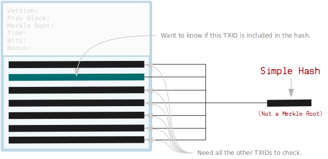

Unefficient example: all transactions at once

## How exactly are the transactions hashed?

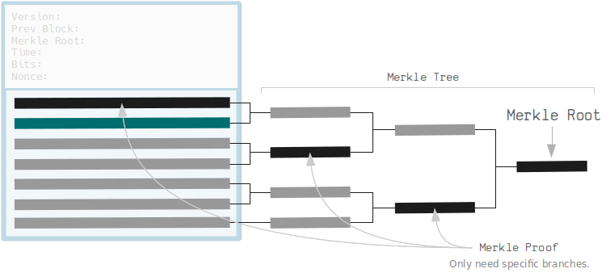

Transactions at leaves of the tree

# Finally, we get

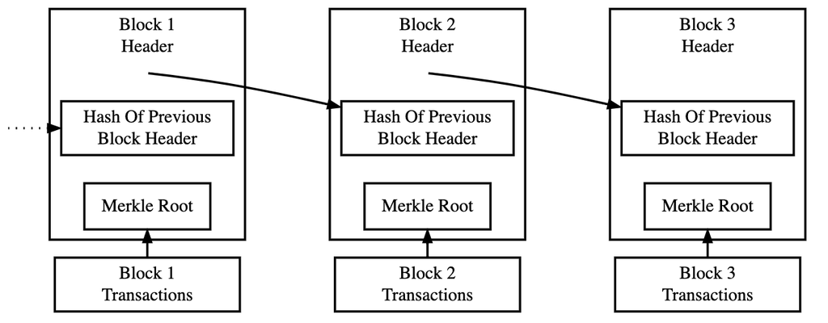

Working example

# Reminder

- The longest chain is considered the truth
- To make the chain longer, you need to solve cryptographical puzzles  
  hence it is called the **proof-of-work** consensus model
- Transactions are probabilistically immutable

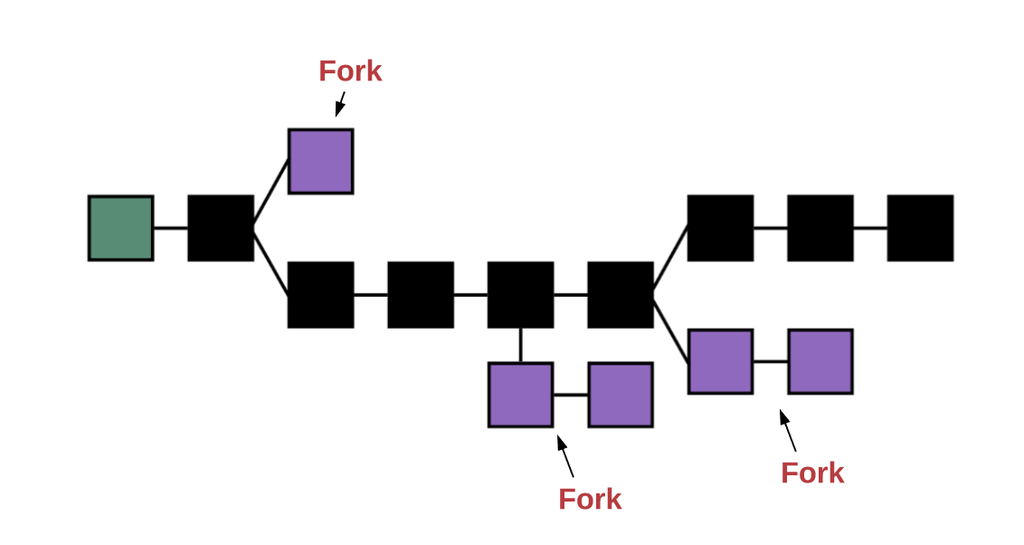

# Comparison

|  | Bitcoin | Blockchain |
| --- | --- | --- |
| Permissionless |  |  |
| Immutable |  |  |
| Public |  |  |
| Decentralized |  |  |
| Independent of a third party |  |  |

# Comparison 2

|  | Bitcoin | Blockchain |
| --- | --- | --- |
| Permissionless |  | Not necessarily |
| Immutable |  | Not necessarily |
| Public |  | Not necessarily |
| Decentralized |  | Not necessarily |
| Independent of a third party |  | Not necessarily |

# Comparison 3

[figure not shown]

# Performance

|  | Throughput |
| --- | --- |
| Bitcoin | 27 transactions / sec |
| Ripple | 1500 transactions / sec |
| Scaling blockchain with sharding - research paper | 2000-4000 transactions / sec |
| Visa workload | 65000+ transactions / sec |

# Wrap up

- Bitcoin - permissionless, immutable, public cryptocurrency
- Blockchain = “distributed ledger” -  
  not necessarily same attributes than Bitcoin has
- Throughput issues